# TCJA effect on hospital industry

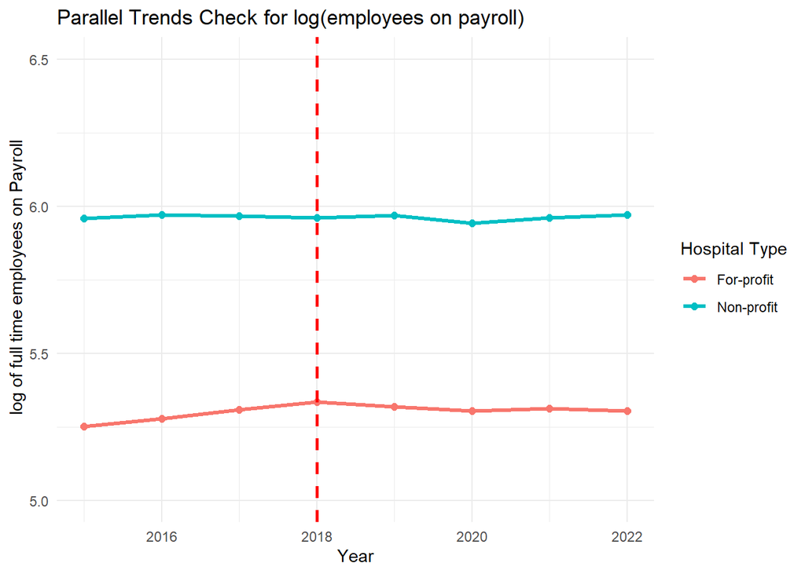

```r
data_all_years_filtered$LOGFTE...Employees.on.Payroll <- log(data_all_years_filtered$FTE...Employees.on.Payroll)

data_all_years_plotFTEpayrolllog <- data_all_years_filtered %>%
  group_by(Year, Type.of.Control) %>%
  summarise(avg_LOGFTEpayroll = median(LOGFTE...Employees.on.Payroll, na.rm = TRUE))
ggplot(data_all_years_plotFTEpayrolllog, aes(x = Year, y = avg_LOGFTEpayroll, color = Type.of.Control, group = Type.of.Control)) +
  geom_line(linewidth = 1.2) +
  geom_point(size = 2) +
  geom_vline(xintercept = 2018, linetype = "dashed", color = "red", linewidth = 1) +
  labs(x = "Year", y = " log of full time employees on Payroll", color = "Hospital Type",
       title = "Parallel Trends Check for log(employees on payroll)") +
  theme_minimal() +
  ylim(5, 6.5)
```

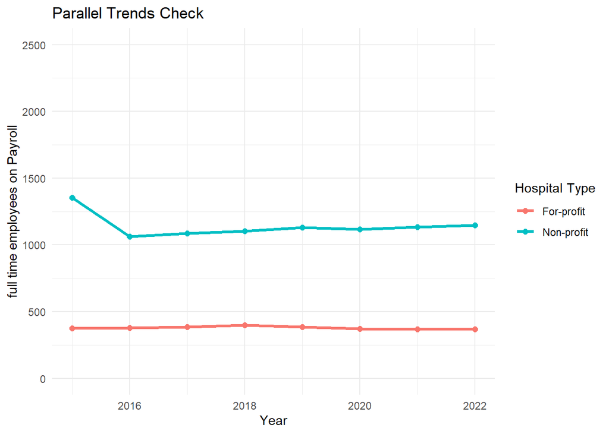

```r
data_all_years_plotFTEpayroll <- data_all_years_filtered %>%
  group_by(Year, Type.of.Control) %>%
  summarise(avg_FTEpayroll = mean(FTE...Employees.on.Payroll, na.rm = TRUE))
ggplot(data_all_years_plotFTEpayroll, aes(x = Year, y = avg_FTEpayroll, color = Type.of.Control, group = Type.of.Control)) +
  geom_line(linewidth = 1.2) +
  geom_point(size = 2) +
  labs(x = "Year", y = "full time employees on Payroll", color = "Hospital Type",
       title = "Parallel Trends Check") +
  theme_minimal() +
  ylim(0, 2500)
```

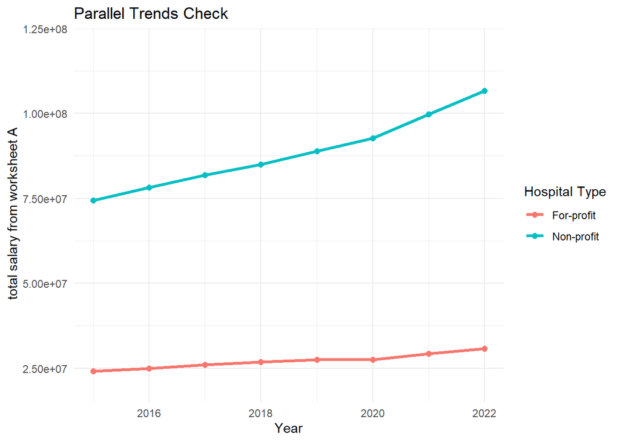

```r
data_all_years_plotsalary <- data_all_years_filtered %>%
  group_by(Year, Type.of.Control) %>%
  summarise(avg_salary = mean(Total.Salaries.From.Worksheet.A, na.rm = TRUE))
ggplot(data_all_years_plotsalary, aes(x = Year, y = avg_salary, color = Type.of.Control, group = Type.of.Control)) +
  geom_line(linewidth = 1.2) +
  geom_point(size = 2) +
  labs(x = "Year", y = " total salary from worksheet A", color = "Hospital Type",
       title = "Parallel Trends Check") +
  theme_minimal() +
  ylim(20000000, 120000000)
```

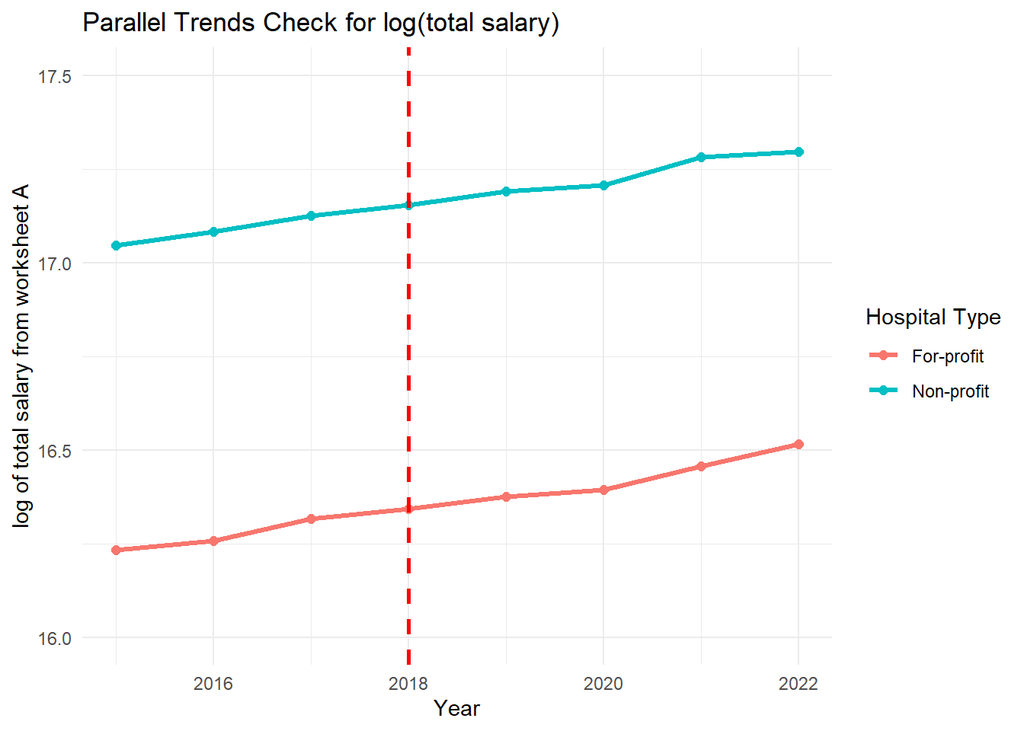

```r
data_all_years_filtered$Total.Salaries.From.Worksheet.ALOG <- log(data_all_years_filtered$Total.Salaries.From.Worksheet.A)

data_all_years_plotsalaryLOG <- data_all_years_filtered %>%
  group_by(Year, Type.of.Control) %>%
  summarise(avg_salaryLOG = median(Total.Salaries.From.Worksheet.ALOG, na.rm = TRUE))
ggplot(data_all_years_plotsalaryLOG, aes(x = Year, y = avg_salaryLOG, color = Type.of.Control, group = Type.of.Control)) +
  geom_line(linewidth = 1.2) +
  geom_point(size = 2) +
  geom_vline(xintercept = 2018, linetype = "dashed", color = "red", linewidth = 1) +
  labs(x = "Year", y = "log of total salary from worksheet A", color = "Hospital Type",
       title = "Parallel Trends Check for log(total salary)") +
  theme_minimal() +
  ylim(16,17.5)
```

```r
data_all_years_filtered$Total.Income.ALOG <- log(data_all_years_filtered$Total.Income)
```

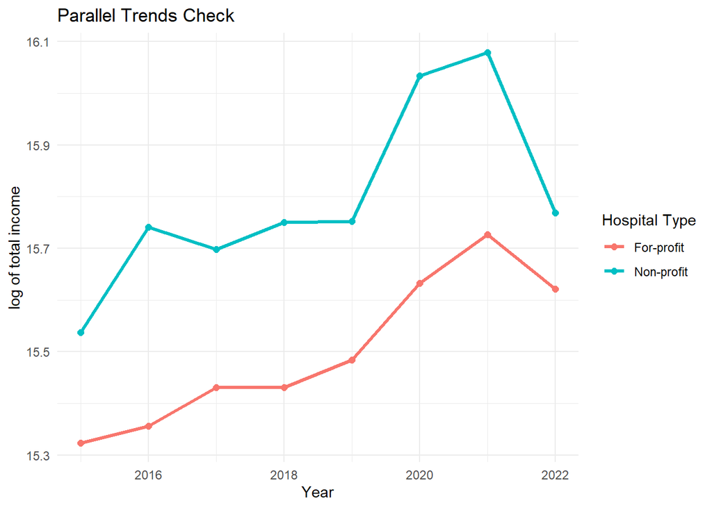

```r
data_all_years_plotincomeLOG <- data_all_years_filtered %>%
  group_by(Year, Type.of.Control) %>%
  summarise(avg_incomeLOG = mean(Total.Income.ALOG, na.rm = TRUE))
ggplot(data_all_years_plotincomeLOG, aes(x = Year, y = avg_incomeLOG, color = Type.of.Control, group = Type.of.Control)) +
  geom_line(linewidth = 1.2) +
  geom_point(size = 2) +
  labs(x = "Year", y = "log of total income", color = "Hospital Type",
       title = "Parallel Trends Check") +
  theme_minimal()
```

```r
data_all_years_filtered %>%
  filter(Hospital.Name == "THE REHAB HOSPITAL AT RARITAN BAY") %>%
  select(Year, Number.of.Beds)
```

```
## # A tibble: 8 × 3
## # Groups:   Hospital.Name [1]
##   Hospital.Name                      Year Number.of.Beds
##   <chr>                             <dbl>          <int>
## 1 THE REHAB HOSPITAL AT RARITAN BAY  2015        6092016
## 2 THE REHAB HOSPITAL AT RARITAN BAY  2016             76
## 3 THE REHAB HOSPITAL AT RARITAN BAY  2017             76
## 4 THE REHAB HOSPITAL AT RARITAN BAY  2018             76
## 5 THE REHAB HOSPITAL AT RARITAN BAY  2019             76
## 6 THE REHAB HOSPITAL AT RARITAN BAY  2020             76
## 7 THE REHAB HOSPITAL AT RARITAN BAY  2021             76
## 8 THE REHAB HOSPITAL AT RARITAN BAY  2022             76
```

```r
data_all_years_filtered %>%
  filter(Hospital.Name == "HOAG ORTHOPEDIC INSTITUTE") %>%
  select(Total.Salaries.From.Worksheet.A)
```

```
## # A tibble: 8 × 2
## # Groups:   Hospital.Name [1]
##   Hospital.Name             Total.Salaries.From.Worksheet.A
##   <chr>                                               <dbl>
## 1 HOAG ORTHOPEDIC INSTITUTE                               1
## 2 HOAG ORTHOPEDIC INSTITUTE                               1
## 3 HOAG ORTHOPEDIC INSTITUTE                          862092
## 4 HOAG ORTHOPEDIC INSTITUTE                         1621644
## 5 HOAG ORTHOPEDIC INSTITUTE                         1516749
## 6 HOAG ORTHOPEDIC INSTITUTE                        10435064
## 7 HOAG ORTHOPEDIC INSTITUTE                        29062248
## 8 HOAG ORTHOPEDIC INSTITUTE                        33284924
```

```r
data_all_years_filtered %>%
  filter(Hospital.Name == "STAFFORD COUNTY HOSPITAL") %>%
  select(FTE...Employees.on.Payroll)
```

```
## # A tibble: 8 × 2
## # Groups:   Hospital.Name [1]
##   Hospital.Name            FTE...Employees.on.Payroll
##   <chr>                                         <dbl>
## 1 STAFFORD COUNTY HOSPITAL                      38.7
## 2 STAFFORD COUNTY HOSPITAL                      38.4
## 3 STAFFORD COUNTY HOSPITAL                      40.1
## 4 STAFFORD COUNTY HOSPITAL                       1
## 5 STAFFORD COUNTY HOSPITAL                       3.05
## 6 STAFFORD COUNTY HOSPITAL                       0.07
## 7 STAFFORD COUNTY HOSPITAL                       4.04
## 8 STAFFORD COUNTY HOSPITAL                       6.31
```

```r
data_all_years_filtered %>%
  filter(Hospital.Name == "LYNN HOUSE OF POTOMAC VALLEY  INC.") %>%
  select(Number.of.Beds)
```

```
## # A tibble: 8 × 2
## # Groups:   Hospital.Name [1]
##   Hospital.Name                      Number.of.Beds
##   <chr>                                       <int>
## 1 LYNN HOUSE OF POTOMAC VALLEY  INC.              4
## 2 LYNN HOUSE OF POTOMAC VALLEY  INC.              8
## 3 LYNN HOUSE OF POTOMAC VALLEY  INC.              6
## 4 LYNN HOUSE OF POTOMAC VALLEY  INC.              5
## 5 LYNN HOUSE OF POTOMAC VALLEY  INC.              2
## 6 LYNN HOUSE OF POTOMAC VALLEY  INC.              1
## 7 LYNN HOUSE OF POTOMAC VALLEY  INC.              1
## 8 LYNN HOUSE OF POTOMAC VALLEY  INC.              5
```

```r
data_all_years_filtered %>%
  filter(Hospital.Name == "WAYNE HOSPITAL COMPANY") %>%
  select(Number.of.Beds)
```

```
## # A tibble: 8 × 2
## # Groups:   Hospital.Name [1]
##   Hospital.Name          Number.of.Beds
##   <chr>                           <int>
## 1 WAYNE HOSPITAL COMPANY             63
## 2 WAYNE HOSPITAL COMPANY             63
## 3 WAYNE HOSPITAL COMPANY             36
## 4 WAYNE HOSPITAL COMPANY             40
## 5 WAYNE HOSPITAL COMPANY             40
## 6 WAYNE HOSPITAL COMPANY        1594784
## 7 WAYNE HOSPITAL COMPANY             40
## 8 WAYNE HOSPITAL COMPANY             43
```

```r
data_all_years_filtered %>%
  filter(Hospital.Name == "BEAR LAKE MEMORIAL HOSPITAL") %>%
  select(Number.of.Beds)
```

```
## # A tibble: 8 × 2
## # Groups:   Hospital.Name [1]
##   Hospital.Name               Number.of.Beds
##   <chr>                                <int>
## 1 BEAR LAKE MEMORIAL HOSPITAL             21
## 2 BEAR LAKE MEMORIAL HOSPITAL             21
## 3 BEAR LAKE MEMORIAL HOSPITAL             21
## 4 BEAR LAKE MEMORIAL HOSPITAL             21
## 5 BEAR LAKE MEMORIAL HOSPITAL          52913
## 6 BEAR LAKE MEMORIAL HOSPITAL             21
## 7 BEAR LAKE MEMORIAL HOSPITAL             21
## 8 BEAR LAKE MEMORIAL HOSPITAL             21
```

```r
data_all_years_filtered %>%
  filter(Hospital.Name == "OKLAHOMA HEART HOSPITAL") %>%
  select(Number.of.Beds)
```

```
## # A tibble: 8 × 2
## # Groups:   Hospital.Name [1]
##   Hospital.Name           Number.of.Beds
##   <chr>                            <int>
## 1 OKLAHOMA HEART HOSPITAL             99
## 2 OKLAHOMA HEART HOSPITAL             99
## 3 OKLAHOMA HEART HOSPITAL             99
## 4 OKLAHOMA HEART HOSPITAL             99
## 5 OKLAHOMA HEART HOSPITAL          28401
## 6 OKLAHOMA HEART HOSPITAL             97
## 7 OKLAHOMA HEART HOSPITAL             97
## 8 OKLAHOMA HEART HOSPITAL             97
```

```r
data_all_years_filtered <- data_all_years_filtered %>%
  mutate(Number.of.Beds = ifelse(
    Hospital.Name == "THE REHAB HOSPITAL AT RARITAN BAY" & Year == 2015,
    76,
    Number.of.Beds
  ))

data_all_years_filtered <- data_all_years_filtered %>%
  mutate(Number.of.Beds = ifelse(
    Hospital.Name == "WAYNE HOSPITAL COMPANY" & Year == 2020,
    63,
    Number.of.Beds
  ))

data_all_years_filtered <- data_all_years_filtered %>%
  mutate(Number.of.Beds = ifelse(
    Hospital.Name == "BEAR LAKE MEMORIAL HOSPITAL" & Year == 2019,
    97,
    Number.of.Beds
  ))

data_all_years_filtered <- data_all_years_filtered %>%
  mutate(Number.of.Beds = ifelse(
    Hospital.Name == "OKLAHOMA HEART HOSPITAL" & Year == 2019,
    97,
    Number.of.Beds
))

data_all_years_filtered <- data_all_years_filtered %>%
  filter(Hospital.Name != "HOAG ORTHOPEDIC INSTITUTE")
```

```r
data_all_years_bed <- data_all_years_filtered %>%
  group_by(Year, Type.of.Control) %>%
  summarise(avg_bedLOG = mean(Number.of.Beds, na.rm = TRUE))
```

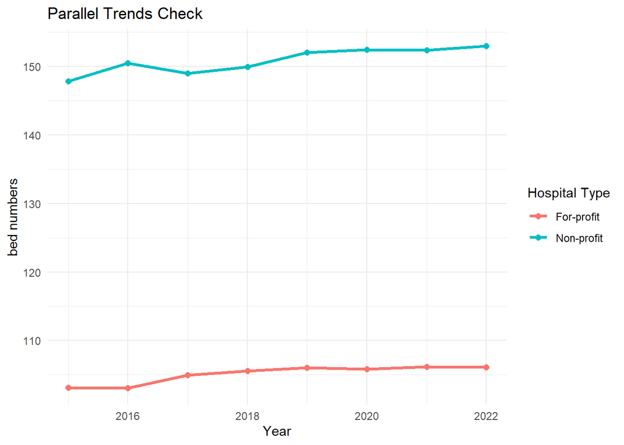

```r
ggplot(data_all_years_bed, aes(x = Year, y = avg_bedLOG, color = Type.of.Control, group = Type.of.Control)) +
  geom_line(linewidth = 1.2) +
  geom_point(size = 2) +
  labs(x = "Year", y = "bed numbers", color = "Hospital Type",
       title = "Parallel Trends Check") +
  theme_minimal()
```

```r
data_all_years_filtered <- data_all_years_filtered %>% mutate(logDischarge = log(Total.Discharges.Title.XVIII))

data_all_years_filtered <- data_all_years_filtered %>% mutate(logTotalCosts = log(Total.Costs))

numeric_vars <- data_all_years_filtered %>%
  ungroup() %>%
  select(
    LOGFTE...Employees.on.Payroll,
    Total.Salaries.From.Worksheet.ALOG,
    Number.of.Beds,
    logDischarge,
    logTotalCosts
  )

# Summary statistics
numeric_summary <- numeric_vars %>%
  summarise_all(list(
    Mean = ~mean(., na.rm = TRUE),
    SD = ~sd(., na.rm = TRUE),
    Min = ~min(., na.rm = TRUE),
    Max = ~max(., na.rm = TRUE),
    Median = ~median(., na.rm = TRUE)
  )) %>%
  pivot_longer(
    cols = everything(),
    names_to = c("Variable", "Statistic"),
    names_sep = "_"
  ) %>%
  pivot_wider(names_from = Statistic, values_from = value)

numeric_summary <- numeric_summary %>%
  mutate(across(where(is.numeric), ~ format(round(., 2), big.mark = ",", scientific = FALSE)))

numeric_summary %>%
  kable(
    caption = "Descriptive Statistics of Numeric Hospital Variables",
    align = "lccccc",
    col.names = c("Variable", "Mean", "SD", "Min", "Max", "Median"),
    format = "html"
  ) %>%
  kable_styling(
    bootstrap_options = c("striped", "hover", "condensed", "responsive"),
    full_width = FALSE,
    font_size = 14
  ) %>%
  column_spec(1, bold = TRUE) %>%
  column_spec(2:6, width = "6em")
```

Descriptive Statistics of Numeric Hospital Variables

| Variable | Mean | SD | Min | Max | Median |
| --- | --- | --- | --- | --- | --- |
| LOGFTE…Employees.on.Payroll | 5.87 | 1.31 | -2.66 | 13.37 | 5.69 |
| Total.Salaries.From.Worksheet.ALOG | 17.05 | 1.38 | 11.12 | 21.86 | 16.86 |
| Number.of.Beds | 137.35 | 180.41 | 1.00 | 3,716.00 | 65.00 |
| logDischarge | 6.27 | 1.64 | 0.00 | 10.01 | 6.17 |
| logTotalCosts | 17.84 | 1.41 | 13.80 | 22.23 | 17.65 |

```r
numeric_vars <- data_all_years_filtered %>%
  ungroup() %>%
  select(
    for_profit,
    LOGFTE...Employees.on.Payroll,
    Total.Salaries.From.Worksheet.ALOG,
    Number.of.Beds,
    logDischarge,
    logTotalCosts
  )

# Compute summary statistics by ownership type
numeric_summary_by_group <- numeric_vars %>%
  group_by(for_profit) %>%
  summarise(across(
    .cols = c(
      LOGFTE...Employees.on.Payroll,
      Total.Salaries.From.Worksheet.ALOG,
      Number.of.Beds,
      logDischarge,
      logTotalCosts
    ),
    .fns = list(
      Mean = ~mean(., na.rm = TRUE),
      SD = ~sd(., na.rm = TRUE),
      Min = ~min(., na.rm = TRUE),
      Max = ~max(., na.rm = TRUE),
      Median = ~median(., na.rm = TRUE)
    ),
    .names = "{.col}_{.fn}"
  )) %>%
  pivot_longer(
    cols = -for_profit,
    names_to = c("Variable", "Statistic"),
    names_sep = "_"
  ) %>%
  pivot_wider(names_from = Statistic, values_from = value) %>%
  mutate(across(where(is.numeric), ~ round(., 2))) %>%
  mutate(for_profit = ifelse(for_profit == 1, "For-Profit", "Non-Profit"))

# Format table
numeric_summary_by_group %>%
  kable(
    caption = "Descriptive Statistics by Ownership Type",
    align = "lccccc",
    col.names = c("Ownership Type", "Variable", "Mean", "SD", "Min", "Max", "Median"),
    format = "html"
  ) %>%
  kable_styling(
    bootstrap_options = c("striped", "hover", "condensed", "responsive"),
    full_width = FALSE,
    font_size = 14
  ) %>%
  column_spec(1, bold = TRUE) %>%
  column_spec(3:7, width = "6em")
```

Descriptive Statistics by Ownership Type

| Ownership Type | Variable | Mean | SD | Min | Max | Median |
| --- | --- | --- | --- | --- | --- | --- |
| Non-Profit | LOGFTE…Employees.on.Payroll | 6.06 | 1.39 | -2.66 | 13.37 | 5.96 |
| Non-Profit | Total.Salaries.From.Worksheet.ALOG | 17.26 | 1.44 | 11.12 | 21.86 | 17.17 |
| Non-Profit | Number.of.Beds | 150.89 | 201.95 | 1.00 | 3716.00 | 59.00 |
| Non-Profit | logDischarge | 6.29 | 1.78 | 0.00 | 10.01 | 6.22 |
| Non-Profit | logTotalCosts | 18.04 | 1.47 | 13.80 | 22.23 | 17.91 |
| For-Profit | LOGFTE…Employees.on.Payroll | 5.44 | 0.97 | 2.13 | 9.14 | 5.30 |
| For-Profit | Total.Salaries.From.Worksheet.ALOG | 16.52 | 1.05 | 13.03 | 20.21 | 16.36 |
| For-Profit | Number.of.Beds | 105.11 | 107.08 | 7.00 | 1498.00 | 72.00 |
| For-Profit | logDischarge | 6.22 | 1.23 | 0.00 | 9.55 | 6.11 |
| For-Profit | logTotalCosts | 17.37 | 1.12 | 14.14 | 20.72 | 17.21 |

```r
data_all_years_filtered <- data_all_years_filtered %>%
  mutate(
    post = ifelse(Year >= 2017, 1, 0)
  )
```

```r
did_emp1 <- feols(LOGFTE...Employees.on.Payroll ~ post*for_profit | State.Code + Year, data_all_years_filtered)
```

```
## The variable 'post' has been removed because of collinearity (see $collin.var).
```

```r
summary(did_emp1)
```

```
## OLS estimation, Dep. Var.: LOGFTE...Employees.on.Payroll
## Observations: 24,456
## Fixed-effects: State.Code: 41,  Year: 8
## Standard-errors: IID
##                  Estimate Std. Error    t value  Pr(>|t|)
## for_profit      -0.715314   0.033499 -21.353573 < 2.2e-16 ***
## post:for_profit  0.009998   0.038162   0.261979   0.79334
## ... 1 variable was removed because of collinearity (post)
## ---
## Signif. codes:  0 '***' 0.001 '**' 0.01 '*' 0.05 '.' 0.1 ' ' 1
## RMSE: 1.17856     Adj. R2: 0.190946
##                 Within R2: 0.063403
```

```r
did_emp2 <- feols(LOGFTE...Employees.on.Payroll ~ post*for_profit + Number.of.Beds + Total.Income + Total.Discharges.Title.XVIII + urban| State.Code + Year, data_all_years_filtered)
```

```
## The variable 'post' has been removed because of collinearity (see $collin.var).
```

```r
summary(did_emp2)
```

```
## OLS estimation, Dep. Var.: LOGFTE...Employees.on.Payroll
## Observations: 24,456
## Fixed-effects: State.Code: 41,  Year: 8
## Standard-errors: IID
##                                   Estimate Std. Error    t value  Pr(>|t|)
## for_profit                   -4.468085e-01 0.02064580 -21.641614 < 2.2e-16 ***
## Number.of.Beds                3.159810e-03 0.00004950  63.839476 < 2.2e-16 ***
## Total.Income                 -2.380000e-10 0.00000100  -0.000238   0.99981
## Total.Discharges.Title.XVIII  1.692450e-04 0.00000359  47.136961 < 2.2e-16 ***
## urban                        -3.146482e-01 0.01096035 -28.707862 < 2.2e-16 ***
## post:for_profit              -1.645384e-02 0.02308981  -0.712602   0.47610
## ... 1 variable was removed because of collinearity (post)
## ---
## Signif. codes:  0 '***' 0.001 '**' 0.01 '*' 0.05 '.' 0.1 ' ' 1
## RMSE: 0.712842     Adj. R2: 0.703972
##                  Within R2: 0.657361
```

```r
did_emp3  <-  feols(LOGFTE...Employees.on.Payroll ~ post*for_profit + Number.of.Beds + Total.Income+ Total.Discharges.Title.XVIII + urban | State.Code^Year, data_all_years_filtered)
```

```
## The variable 'post' has been removed because of collinearity (see $collin.var).
```

```r
summary(did_emp3)
```

```
## OLS estimation, Dep. Var.: LOGFTE...Employees.on.Payroll
## Observations: 24,456
## Fixed-effects: State.Code^Year: 328
## Standard-errors: IID
##                                   Estimate Std. Error    t value  Pr(>|t|)
## for_profit                   -4.404804e-01 0.02154111 -20.448363 < 2.2e-16 ***
## Number.of.Beds                3.154513e-03 0.00004989  63.233184 < 2.2e-16 ***
## Total.Income                 -2.440000e-10 0.00000100  -0.000244   0.99981
## Total.Discharges.Title.XVIII  1.696762e-04 0.00000362  46.871795 < 2.2e-16 ***
## urban                        -3.168825e-01 0.01103780 -28.708838 < 2.2e-16 ***
## post:for_profit              -2.560072e-02 0.02445183  -1.046986   0.29512
## ... 1 variable was removed because of collinearity (post)
## ---
## Signif. codes:  0 '***' 0.001 '**' 0.01 '*' 0.05 '.' 0.1 ' ' 1
## RMSE: 0.712092     Adj. R2: 0.701167
##                  Within R2: 0.657855
```

```r
did_emp_noFE <- feols(
  LOGFTE...Employees.on.Payroll ~ for_profit * post,
  data = data_all_years_filtered,
  cluster = ~State.Code
)


model_summary <- broom::tidy(did_emp_noFE, conf.int = TRUE) %>%
  select(term, estimate, conf.low, conf.high, p.value)

kbl(model_summary, digits = 3, caption = "Difference-in-Differences Regression Results") %>%
  kable_paper("striped", full_width = FALSE)
```

Difference-in-Differences Regression Results

| term | estimate | conf.low | conf.high | p.value |
| --- | --- | --- | --- | --- |
| (Intercept) | 6.046 | 5.840 | 6.252 | 0.000 |
| for_profit | -0.630 | -0.858 | -0.402 | 0.000 |
| post | 0.017 | -0.001 | 0.035 | 0.059 |
| for_profit:post | 0.009 | -0.022 | 0.039 | 0.572 |

```r
data_all_years_filtered %>%
  group_by(State.Code, Year) %>%
  summarize(mean_post = mean(post)) %>%
  distinct(mean_post)
```

```
## # A tibble: 82 × 2
## # Groups:   State.Code [41]
##    State.Code mean_post
##    <chr>          <dbl>
##  1 AK                 0
##  2 AK                 1
##  3 AL                 0
##  4 AL                 1
##  5 AR                 0
##  6 AR                 1
##  7 AZ                 0
##  8 AZ                 1
##  9 CA                 0
## 10 CA                 1
## # ℹ 72 more rows
```

```r
cor(data_all_years_filtered[, c("post", "for_profit", "post_for_profit" = data_all_years$post * data_all_years$for_profit)])
```

```
##                     post    for_profit
## post        1.0000000000 -0.0004371213
## for_profit -0.0004371213  1.0000000000
```

```r
did_sal <- feols(
  Total.Salaries.From.Worksheet.ALOG ~ for_profit * post +
    Number.of.Beds + Total.Discharges.Title.XVIII + Total.Income + urban +
    factor(State.Code):factor(Year),
  data = data_all_years_filtered,
  cluster = ~State.Code
)
```

```
## The variables 'factor(State.Code)WY:factor(Year)2016' and
## 'factor(State.Code)WY:factor(Year)2022' have been removed because of
## collinearity (see $collin.var).
```

```r
model_summary <- broom::tidy(did_sal, conf.int = TRUE) %>%
  select(term, estimate, conf.low, conf.high, p.value)

kbl(model_summary, digits = 3, caption = "Difference-in-Differences Regression Results") %>%
  kable_paper("striped", full_width = FALSE)
```

Difference-in-Differences Regression Results

| term | estimate | conf.low | conf.high | p.value |
| --- | --- | --- | --- | --- |
| (Intercept) | 16.576 | 16.492 | 16.661 | 0.000 |
| for_profit | -0.510 | -0.631 | -0.388 | 0.000 |
| post | 0.349 | 0.338 | 0.360 | 0.000 |
| Number.of.Beds | 0.003 | 0.002 | 0.004 | 0.000 |
| Total.Discharges.Title.XVIII | 0.000 | 0.000 | 0.000 | 0.000 |
| Total.Income | 0.000 | 0.000 | 0.000 | 1.000 |
| urban | -0.322 | -0.418 | -0.226 | 0.000 |
| for_profit:post | -0.033 | -0.055 | -0.012 | 0.003 |
| factor(State.Code)AK:factor(Year)2015 | 0.558 | 0.532 | 0.585 | 0.000 |
| factor(State.Code)AL:factor(Year)2015 | -0.505 | -0.567 | -0.442 | 0.000 |
| factor(State.Code)AR:factor(Year)2015 | -0.450 | -0.481 | -0.419 | 0.000 |
| factor(State.Code)AZ:factor(Year)2015 | 0.188 | 0.115 | 0.261 | 0.000 |
| factor(State.Code)CA:factor(Year)2015 | 0.429 | 0.338 | 0.520 | 0.000 |
| factor(State.Code)CO:factor(Year)2015 | 0.081 | 0.043 | 0.120 | 0.000 |
| factor(State.Code)DC:factor(Year)2015 | 0.479 | 0.367 | 0.590 | 0.000 |
| factor(State.Code)DE:factor(Year)2015 | -0.105 | -0.213 | 0.002 | 0.055 |
| factor(State.Code)FL:factor(Year)2015 | -0.234 | -0.333 | -0.135 | 0.000 |
| factor(State.Code)GA:factor(Year)2015 | -0.123 | -0.168 | -0.078 | 0.000 |
| factor(State.Code)ID:factor(Year)2015 | -0.085 | -0.103 | -0.066 | 0.000 |
| factor(State.Code)IL:factor(Year)2015 | 0.086 | 0.029 | 0.142 | 0.004 |
| factor(State.Code)IN:factor(Year)2015 | -0.096 | -0.151 | -0.041 | 0.001 |
| factor(State.Code)KS:factor(Year)2015 | -0.665 | -0.672 | -0.657 | 0.000 |
| factor(State.Code)KY:factor(Year)2015 | -0.241 | -0.279 | -0.203 | 0.000 |
| factor(State.Code)LA:factor(Year)2015 | -0.682 | -0.742 | -0.623 | 0.000 |
| factor(State.Code)MA:factor(Year)2015 | 0.304 | 0.203 | 0.405 | 0.000 |
| factor(State.Code)MI:factor(Year)2015 | 0.050 | 0.000 | 0.099 | 0.049 |
| factor(State.Code)MO:factor(Year)2015 | -0.109 | -0.151 | -0.067 | 0.000 |
| factor(State.Code)MS:factor(Year)2015 | -0.363 | -0.390 | -0.337 | 0.000 |
| factor(State.Code)NC:factor(Year)2015 | -0.101 | -0.165 | -0.036 | 0.003 |
| factor(State.Code)ND:factor(Year)2015 | -0.726 | -0.740 | -0.712 | 0.000 |

[output cut: 304 more lines]

```r
data_did_20172019period <- subset(data_all_years_filtered, Year %in% c(2017, 2019))
data_did_20172019period$post <- ifelse(data_did_20172019period$Year == 2019, 1, 0)
did_emp20172019 <- feols(LOGFTE...Employees.on.Payroll ~ post*for_profit , data_did_20172019period)
summary(did_emp20172019)
```

```
## OLS estimation, Dep. Var.: LOGFTE...Employees.on.Payroll
## Observations: 6,114
## Standard-errors: IID
##                  Estimate Std. Error    t value  Pr(>|t|)
## (Intercept)      6.060678   0.027519 220.236367 < 2.2e-16 ***
## post             0.010903   0.038913   0.280186   0.77934
## for_profit      -0.610285   0.050617 -12.056990 < 2.2e-16 ***
## post:for_profit -0.003651   0.071539  -0.051037   0.95930
## ---
## Signif. codes:  0 '***' 0.001 '**' 0.01 '*' 0.05 '.' 0.1 ' ' 1
## RMSE: 1.27618   Adj. R2: 0.045282
```

```r
cor(data_did_20172019period$for_profit, data_did_20172019period$post)
```

```
## [1] 0.0006509183
```

```r
cor(data_did_20172019period$for_profit, data_did_20172019period$for_profit * data_did_20172019period$post)
```

```
## [1] 0.643422
```

```r
did_emp20172019Sal <- feols(Total.Salaries.From.Worksheet.ALOG ~ post*for_profit , data_did_20172019period)
summary(did_emp20172019Sal)
```

```
## OLS estimation, Dep. Var.: Total.Salaries.From.Worksheet.ALOG
## Observations: 6,114
## Standard-errors: IID
##                  Estimate Std. Error    t value  Pr(>|t|)
## (Intercept)     17.207114   0.028615 601.327560 < 2.2e-16 ***
## post             0.065347   0.040463   1.614968   0.10637
## for_profit      -0.721401   0.052633 -13.706228 < 2.2e-16 ***
## post:for_profit -0.003771   0.074388  -0.050697   0.95957
## ---
## Signif. codes:  0 '***' 0.001 '**' 0.01 '*' 0.05 '.' 0.1 ' ' 1
## RMSE: 1.32702   Adj. R2: 0.058335
```

```r
data_did_20172020period <- subset(data_all_years_filtered, Year %in% c(2017, 2020))
data_did_20172020period$post <- ifelse(data_did_20172020period$Year == 2020, 1, 0)
did_emp20172020 <- feols(LOGFTE...Employees.on.Payroll ~ post*for_profit , data_did_20172020period)
summary(did_emp20172020)
```

```
## OLS estimation, Dep. Var.: LOGFTE...Employees.on.Payroll
## Observations: 6,113
## Standard-errors: IID
##                  Estimate Std. Error    t value  Pr(>|t|)
## (Intercept)      6.060678   0.027587 219.693312 < 2.2e-16 ***
## post            -0.005918   0.039009  -0.151704   0.87943
## for_profit      -0.610285   0.050742 -12.027260 < 2.2e-16 ***
## post:for_profit -0.004115   0.071729  -0.057373   0.95425
## ---
## Signif. codes:  0 '***' 0.001 '**' 0.01 '*' 0.05 '.' 0.1 ' ' 1
## RMSE: 1.27933   Adj. R2: 0.045085
```

```r
did_emp20172020Sal <- feols(Total.Salaries.From.Worksheet.ALOG ~ post*for_profit , data_did_20172020period)
summary(did_emp20172020Sal)
```

```
## OLS estimation, Dep. Var.: Total.Salaries.From.Worksheet.ALOG
## Observations: 6,113
## Standard-errors: IID
##                  Estimate Std. Error    t value  Pr(>|t|)
## (Intercept)     17.207114   0.028543 602.848659 < 2.2e-16 ***
## post             0.104277   0.040361   2.583591 0.0098008 **
## for_profit      -0.721401   0.052500 -13.740899 < 2.2e-16 ***
## post:for_profit -0.031247   0.074215  -0.421039 0.6737416
## ---
## Signif. codes:  0 '***' 0.001 '**' 0.01 '*' 0.05 '.' 0.1 ' ' 1
## RMSE: 1.32367   Adj. R2: 0.061355
```

```r
data_did_20172021period <- subset(data_all_years_filtered, Year %in% c(2017, 2021))
data_did_20172021period$post <- ifelse(data_did_20172021period$Year == 2021, 1, 0)
did_emp20172021 <- feols(LOGFTE...Employees.on.Payroll ~ post*for_profit , data_did_20172021period)
summary(did_emp20172021)
```

```
## OLS estimation, Dep. Var.: LOGFTE...Employees.on.Payroll
## Observations: 6,115
## Standard-errors: IID
##                  Estimate Std. Error    t value  Pr(>|t|)
## (Intercept)      6.060678   0.027569 219.837014 < 2.2e-16 ***
## post             0.000289   0.038979   0.007411   0.99409
## for_profit      -0.610285   0.050709 -12.035127 < 2.2e-16 ***
## post:for_profit -0.028498   0.071666  -0.397652   0.69090
## ---
## Signif. codes:  0 '***' 0.001 '**' 0.01 '*' 0.05 '.' 0.1 ' ' 1
## RMSE: 1.2785   Adj. R2: 0.046923
```

```r
did_emp20172021Sal <- feols(Total.Salaries.From.Worksheet.ALOG ~ post*for_profit , data_did_20172021period)
summary(did_emp20172021Sal)
```

```
## OLS estimation, Dep. Var.: Total.Salaries.From.Worksheet.ALOG
## Observations: 6,115
## Standard-errors: IID
##                  Estimate Std. Error    t value   Pr(>|t|)
## (Intercept)     17.207114   0.028601 601.620746  < 2.2e-16 ***
## post             0.170387   0.040439   4.213443 2.5513e-05 ***
## for_profit      -0.721401   0.052607 -13.712911  < 2.2e-16 ***
## post:for_profit -0.045367   0.074350  -0.610182 5.4176e-01
## ---
## Signif. codes:  0 '***' 0.001 '**' 0.01 '*' 0.05 '.' 0.1 ' ' 1
## RMSE: 1.32637   Adj. R2: 0.064184
```

```r
data_did_20172022period <- subset(data_all_years_filtered, Year %in% c(2017, 2022))
data_did_20172022period$post <- ifelse(data_did_20172022period$Year == 2022, 1, 0)
did_emp20172022 <- feols(LOGFTE...Employees.on.Payroll ~ post*for_profit , data_did_20172022period)
summary(did_emp20172022)
```

```
## OLS estimation, Dep. Var.: LOGFTE...Employees.on.Payroll
## Observations: 6,105
## Standard-errors: IID
##                  Estimate Std. Error    t value  Pr(>|t|)
## (Intercept)      6.060678   0.027579 219.753723 < 2.2e-16 ***
## post             0.009558   0.039008   0.245020   0.80645
## for_profit      -0.610285   0.050728 -12.030567 < 2.2e-16 ***
## post:for_profit -0.050813   0.071799  -0.707716   0.47915
## ---
## Signif. codes:  0 '***' 0.001 '**' 0.01 '*' 0.05 '.' 0.1 ' ' 1
## RMSE: 1.27898   Adj. R2: 0.048486
```

```r
did_emp20172022Sal <- feols(Total.Salaries.From.Worksheet.ALOG ~ post*for_profit , data_did_20172022period)
summary(did_emp20172022Sal)
```

```
## OLS estimation, Dep. Var.: Total.Salaries.From.Worksheet.ALOG
## Observations: 6,105
## Standard-errors: IID
##                  Estimate Std. Error    t value   Pr(>|t|)
## (Intercept)     17.207114   0.028685 599.859323  < 2.2e-16 ***
## post             0.223933   0.040572   5.519421 3.5413e-08 ***
## for_profit      -0.721401   0.052762 -13.672762  < 2.2e-16 ***
## post:for_profit -0.052792   0.074678  -0.706937 4.7963e-01
## ---
## Signif. codes:  0 '***' 0.001 '**' 0.01 '*' 0.05 '.' 0.1 ' ' 1
## RMSE: 1.33026   Adj. R2: 0.066693
```

```r
data_did_20172019period <- subset(data_all_years_filtered, Year %in% c(2017, 2019))
data_did_20172019period$post <- ifelse(data_did_20172019period$Year == 2019, 1, 0)
did_emp20172019C <- feols(LOGFTE...Employees.on.Payroll ~ post*for_profit +
    Number.of.Beds + Total.Discharges.Title.XVIII +  urban , data_did_20172019period)
summary(did_emp20172019C)
```

```
## OLS estimation, Dep. Var.: LOGFTE...Employees.on.Payroll
## Observations: 6,114
## Standard-errors: IID
##                               Estimate Std. Error    t value  Pr(>|t|)
## (Intercept)                   5.479239 0.02288663 239.407869 < 2.2e-16 ***
## post                          0.034304 0.02265800   1.514009   0.13008
## for_profit                   -0.484373 0.03075199 -15.750944 < 2.2e-16 ***
## Number.of.Beds                0.003264 0.00010542  30.962541 < 2.2e-16 ***
## Total.Discharges.Title.XVIII  0.000159 0.00000710  22.332752 < 2.2e-16 ***
## urban                        -0.443415 0.02189128 -20.255329 < 2.2e-16 ***
## post:for_profit              -0.014557 0.04157664  -0.350135   0.72625
## ---
## Signif. codes:  0 '***' 0.001 '**' 0.01 '*' 0.05 '.' 0.1 ' ' 1
## RMSE: 0.741382   Adj. R2: 0.677633
```

```r
data_did_20172019periodF <- subset(data_all_years, Year %in% c(2017, 2019))
data_did_20172019periodF$post <- ifelse(data_did_20172019periodF$Year == 2019, 1, 0)
did_emp20172019F <- feols(log(FTE...Employees.on.Payroll) ~ post*for_profit +
    Number.of.Beds + log(Total.Discharges.Title.XVIII) +  log(Total.Costs) +urban | State.Code, data_did_20172019periodF , vcov = "hetero")
summary(did_emp20172019F)
```

```
## OLS estimation, Dep. Var.: log(FTE...Employees.on.Payroll)
## Observations: 7,281
## Fixed-effects: State.Code: 53
## Standard-errors: Heteroskedasticity-robust
##                                    Estimate Std. Error    t value   Pr(>|t|)
## post                              -0.051054   0.009648  -5.291921 1.2460e-07
## for_profit                        -0.101441   0.015606  -6.500274 8.5512e-11
## Number.of.Beds                     0.000016   0.000014   1.117155 2.6397e-01
## log(Total.Discharges.Title.XVIII)  0.032423   0.006217   5.215130 1.8879e-07
## log(Total.Costs)                   0.859437   0.008402 102.291982  < 2.2e-16
## urban                             -0.043148   0.011564  -3.731174 1.9205e-04
## post:for_profit                    0.008228   0.017489   0.470485 6.3802e-01
##
## post                              ***
## for_profit                        ***
## Number.of.Beds
## log(Total.Discharges.Title.XVIII) ***
## log(Total.Costs)                  ***
## urban                             ***
## post:for_profit
## ---
## Signif. codes:  0 '***' 0.001 '**' 0.01 '*' 0.05 '.' 0.1 ' ' 1
## RMSE: 0.340817     Adj. R2: 0.932815
##                  Within R2: 0.920336
```

```r
did_emp20172019salF <- feols(log(Total.Salaries.From.Worksheet.A) ~ post*for_profit +
    Number.of.Beds + log(Total.Discharges.Title.XVIII) +  log(Total.Costs) +urban | State.Code, data_did_20172019periodF , vcov = "hetero")
summary(did_emp20172019salF)
```

```
## OLS estimation, Dep. Var.: log(Total.Salaries.From.Worksheet.A)
## Observations: 7,281
## Fixed-effects: State.Code: 53
## Standard-errors: Heteroskedasticity-robust
##                                    Estimate Std. Error    t value  Pr(>|t|)
## post                              -0.007966   0.007837  -1.016477   0.30944
## for_profit                        -0.116423   0.013782  -8.447519 < 2.2e-16 ***
## Number.of.Beds                     0.000014   0.000010   1.420043   0.15564
## log(Total.Discharges.Title.XVIII) -0.002722   0.004627  -0.588264   0.55637
## log(Total.Costs)                   0.943054   0.007761 121.509291 < 2.2e-16 ***
## urban                             -0.011318   0.010228  -1.106477   0.26856
## post:for_profit                    0.009601   0.014835   0.647150   0.51756
## ---
## Signif. codes:  0 '***' 0.001 '**' 0.01 '*' 0.05 '.' 0.1 ' ' 1
## RMSE: 0.279936     Adj. R2: 0.95876
##                  Within R2: 0.949937
```

```r
data_did_20172020periodF <- subset(data_all_years, Year %in% c(2017, 2020))
data_did_20172020periodF$post <- ifelse(data_did_20172020periodF$Year == 2020, 1, 0)
did_emp20172020F <- feols(log(FTE...Employees.on.Payroll) ~ post*for_profit +
    Number.of.Beds + log(Total.Discharges.Title.XVIII) +  log(Total.Costs) +urban | State.Code, data_did_20172020periodF, vcov = "hetero")
summary(did_emp20172020F)
```

```
## OLS estimation, Dep. Var.: log(FTE...Employees.on.Payroll)
## Observations: 7,280
## Fixed-effects: State.Code: 53
## Standard-errors: Heteroskedasticity-robust
##                                       Estimate Std. Error   t value   Pr(>|t|)
## post                              -0.082534942 0.01272283 -6.487150 9.3253e-11
## for_profit                        -0.094199153 0.01579766 -5.962854 2.5955e-09
## Number.of.Beds                     0.000000017 0.00000100  0.016952 9.8648e-01
## log(Total.Discharges.Title.XVIII)  0.028237307 0.00792664  3.562329 3.6995e-04
## log(Total.Costs)                   0.855883342 0.00959468 89.203972  < 2.2e-16
## urban                             -0.047045606 0.01377104 -3.416271 6.3835e-04
## post:for_profit                    0.012477186 0.01957310  0.637466 5.2384e-01
##
## post                              ***
## for_profit                        ***
## Number.of.Beds
## log(Total.Discharges.Title.XVIII) ***
## log(Total.Costs)                  ***
## urban                             ***
## post:for_profit
## ---
## Signif. codes:  0 '***' 0.001 '**' 0.01 '*' 0.05 '.' 0.1 ' ' 1
## RMSE: 0.43155     Adj. R2: 0.894582
##                 Within R2: 0.875953
```

```r
did_emp20172020salF <- feols(log(Total.Salaries.From.Worksheet.A) ~ post*for_profit +
    Number.of.Beds + log(Total.Discharges.Title.XVIII) +  log(Total.Costs) +urban | State.Code, data_did_20172020periodF , vcov = "hetero")
summary(did_emp20172020salF)
```

```
## OLS estimation, Dep. Var.: log(Total.Salaries.From.Worksheet.A)
## Observations: 7,280
## Fixed-effects: State.Code: 53
## Standard-errors: Heteroskedasticity-robust
##                                       Estimate Std. Error    t value  Pr(>|t|)
## post                              -0.017233366 0.00830133  -2.075976  0.037931
## for_profit                        -0.117202551 0.01392515  -8.416607 < 2.2e-16
## Number.of.Beds                    -0.000000136 0.00000100  -0.135549  0.892181
## log(Total.Discharges.Title.XVIII) -0.004213551 0.00483923  -0.870707  0.383943
## log(Total.Costs)                   0.943633238 0.00795168 118.670945 < 2.2e-16
## urban                             -0.011818389 0.01019704  -1.159002  0.246494
## post:for_profit                    0.014279348 0.01463301   0.975831  0.329181
##
## post                              *
## for_profit                        ***
## Number.of.Beds
## log(Total.Discharges.Title.XVIII)
## log(Total.Costs)                  ***
## urban
## post:for_profit
## ---
## Signif. codes:  0 '***' 0.001 '**' 0.01 '*' 0.05 '.' 0.1 ' ' 1
## RMSE: 0.28153     Adj. R2: 0.958195
##                 Within R2: 0.949273
```

```r
data_did_20172021periodF <- subset(data_all_years, Year %in% c(2017, 2021))
data_did_20172021periodF$post <- ifelse(data_did_20172021periodF$Year == 2021, 1, 0)
did_emp20172021F <- feols(log(FTE...Employees.on.Payroll) ~ post*for_profit +
    Number.of.Beds + log(Total.Discharges.Title.XVIII) +  log(Total.Costs) +urban | State.Code, data_did_20172021periodF, vcov = "hetero")
summary(did_emp20172021F)
```

```
## OLS estimation, Dep. Var.: log(FTE...Employees.on.Payroll)
## Observations: 7,281
## Fixed-effects: State.Code: 53
## Standard-errors: Heteroskedasticity-robust
##                                    Estimate Std. Error   t value   Pr(>|t|)
## post                              -0.134705   0.013928 -9.671380  < 2.2e-16 ***
## for_profit                        -0.108048   0.016203 -6.668615 2.7729e-11 ***
## Number.of.Beds                     0.000738   0.000056 13.208211  < 2.2e-16 ***
## log(Total.Discharges.Title.XVIII)  0.026195   0.006838  3.831031 1.2869e-04 ***
## log(Total.Costs)                   0.778885   0.013413 58.067941  < 2.2e-16 ***
## urban                             -0.050988   0.013882 -3.672971 2.4148e-04 ***
## post:for_profit                   -0.000904   0.018888 -0.047854 9.6183e-01
## ---
## Signif. codes:  0 '***' 0.001 '**' 0.01 '*' 0.05 '.' 0.1 ' ' 1
## RMSE: 0.42093     Adj. R2: 0.899813
##                 Within R2: 0.882629
```

```r
did_emp20172021salF <- feols(log(Total.Salaries.From.Worksheet.A) ~ post*for_profit +
    Number.of.Beds + log(Total.Discharges.Title.XVIII) +  log(Total.Costs) +urban | State.Code, data_did_20172021periodF , vcov = "hetero")
summary(did_emp20172021salF)
```

```
## OLS estimation, Dep. Var.: log(Total.Salaries.From.Worksheet.A)
## Observations: 7,281
## Fixed-effects: State.Code: 53
## Standard-errors: Heteroskedasticity-robust
##                                    Estimate Std. Error   t value  Pr(>|t|)
## post                              -0.025808   0.008937 -2.887714 0.0038921 **
## for_profit                        -0.124361   0.013801 -9.010839 < 2.2e-16 ***
## Number.of.Beds                     0.000408   0.000039 10.577675 < 2.2e-16 ***
## log(Total.Discharges.Title.XVIII) -0.004032   0.004937 -0.816525 0.4142271
## log(Total.Costs)                   0.900183   0.010608 84.861602 < 2.2e-16 ***
## urban                             -0.011954   0.009859 -1.212583 0.2253291
## post:for_profit                    0.012927   0.014136  0.914476 0.3604972
## ---
## Signif. codes:  0 '***' 0.001 '**' 0.01 '*' 0.05 '.' 0.1 ' ' 1
## RMSE: 0.277624     Adj. R2: 0.959567
##                  Within R2: 0.951196
```

```r
data_did_20172022periodF <- subset(data_all_years, Year %in% c(2017, 2022))
data_did_20172022periodF$post <- ifelse(data_did_20172022periodF$Year == 2022, 1, 0)
did_emp20172022F <- feols(log(FTE...Employees.on.Payroll) ~ post*for_profit +
    Number.of.Beds + log(Total.Discharges.Title.XVIII) +  log(Total.Costs) +urban | State.Code, data_did_20172022periodF, vcov = "hetero")
summary(did_emp20172022F)
```

```
## OLS estimation, Dep. Var.: log(FTE...Employees.on.Payroll)
## Observations: 7,271
## Fixed-effects: State.Code: 53
## Standard-errors: Heteroskedasticity-robust
##                                    Estimate Std. Error    t value   Pr(>|t|)
## post                              -0.182648   0.014347 -12.730412  < 2.2e-16
## for_profit                        -0.102912   0.016193  -6.355503 2.2040e-10
## Number.of.Beds                     0.000701   0.000058  12.096809  < 2.2e-16
## log(Total.Discharges.Title.XVIII)  0.017769   0.006939   2.560781 1.0464e-02
## log(Total.Costs)                   0.791761   0.013335  59.374816  < 2.2e-16
## urban                             -0.048679   0.013839  -3.517408 4.3847e-04
## post:for_profit                    0.002030   0.019060   0.106515 9.1518e-01
##
## post                              ***
## for_profit                        ***
## Number.of.Beds                    ***
## log(Total.Discharges.Title.XVIII) *
## log(Total.Costs)                  ***
## urban                             ***
## post:for_profit
## ---
## Signif. codes:  0 '***' 0.001 '**' 0.01 '*' 0.05 '.' 0.1 ' ' 1
## RMSE: 0.420662     Adj. R2: 0.900437
##                  Within R2: 0.883473
```

```r
did_emp20172022salF <- feols(log(Total.Salaries.From.Worksheet.A) ~ post*for_profit +
    Number.of.Beds + log(Total.Discharges.Title.XVIII) +  log(Total.Costs) +urban | State.Code, data_did_20172022periodF , vcov = "hetero")
summary(did_emp20172022salF)
```

```
## OLS estimation, Dep. Var.: log(Total.Salaries.From.Worksheet.A)
## Observations: 7,271
## Fixed-effects: State.Code: 53
## Standard-errors: Heteroskedasticity-robust
##                                    Estimate Std. Error  t value  Pr(>|t|)
## post                              -0.030395   0.009516 -3.19400 0.0014092 **
## for_profit                        -0.126816   0.013828 -9.17088 < 2.2e-16 ***
## Number.of.Beds                     0.000396   0.000039 10.19665 < 2.2e-16 ***
## log(Total.Discharges.Title.XVIII) -0.005618   0.004865 -1.15474 0.2482339
## log(Total.Costs)                   0.902749   0.010488 86.07245 < 2.2e-16 ***
## urban                             -0.014614   0.009863 -1.48166 0.1384738
## post:for_profit                    0.029939   0.014343  2.08746 0.0368820 *
## ---
## Signif. codes:  0 '***' 0.001 '**' 0.01 '*' 0.05 '.' 0.1 ' ' 1
## RMSE: 0.281151     Adj. R2: 0.958874
##                  Within R2: 0.950449
```

```r
data_diff2019 <- data_all_years_filtered %>%
  filter(Year %in% c(2017, 2019)) %>%
  group_by(Hospital.Name) %>%
  summarize(
    d_TotalSal = diff(Total.Salaries.From.Worksheet.ALOG),
    d_LOGFTE = diff(LOGFTE...Employees.on.Payroll),
    for_profit = first(for_profit),
    d_beds = diff(Number.of.Beds),
    d_income = diff(Total.Income),
    d_discharges = diff(Total.Discharges.Title.XVIII),
    d_urban = diff(urban)
  )
model_diff2019 <- lm(d_LOGFTE ~ for_profit + d_beds + d_income + d_discharges + d_urban,  data = data_diff2019)
model_diff2019sal <- lm(d_TotalSal ~ for_profit + d_beds + d_income + d_discharges + d_urban,  data = data_diff2019)
summary(model_diff2019)
```

```
##
## Call:
## lm(formula = d_LOGFTE ~ for_profit + d_beds + d_income + d_discharges +
##     d_urban, data = data_diff2019)
##
## Residuals:
##      Min       1Q   Median       3Q      Max
## -2.58960 -0.06536 -0.00253  0.05746  2.72647
##
## Coefficients:
##                Estimate Std. Error t value Pr(>|t|)
## (Intercept)   1.323e-02  4.621e-03   2.863  0.00422 **
## for_profit    2.593e-03  8.205e-03   0.316  0.75200
## d_beds        5.098e-04  1.009e-04   5.051 4.67e-07 ***
## d_income     -1.154e-10  5.486e-11  -2.103  0.03554 *
## d_discharges  3.176e-05  7.634e-06   4.160 3.28e-05 ***
## d_urban       2.904e-02  2.076e-02   1.399  0.16194
## ---
## Signif. codes:  0 '***' 0.001 '**' 0.01 '*' 0.05 '.' 0.1 ' ' 1
##
## Residual standard error: 0.2065 on 3051 degrees of freedom
## Multiple R-squared:  0.01616,    Adjusted R-squared:  0.01455
## F-statistic: 10.02 on 5 and 3051 DF,  p-value: 1.569e-09
```

```r
data_diff2020 <- data_all_years_filtered %>%
  filter(Year %in% c(2017, 2020)) %>%
  group_by(Hospital.Name) %>%
  summarize(
    d_TotalSal = diff(Total.Salaries.From.Worksheet.ALOG),
    d_LOGFTE = diff(LOGFTE...Employees.on.Payroll),
    for_profit = first(for_profit),
    d_beds = diff(Number.of.Beds),
    d_income = diff(Total.Income),
    d_discharges = diff(Total.Discharges.Title.XVIII),
    d_urban = diff(urban)
  )
model_diff2020 <- lm(d_LOGFTE ~ for_profit + d_beds + d_income + d_discharges + d_urban,  data = data_diff2020)
model_diff2020sal <- lm(d_TotalSal ~ for_profit + d_beds + d_income + d_discharges + d_urban,  data = data_diff2020)
summary(model_diff2020)
```

```
##
## Call:
## lm(formula = d_LOGFTE ~ for_profit + d_beds + d_income + d_discharges +
##     d_urban, data = data_diff2020)
##
## Residuals:
##     Min      1Q  Median      3Q     Max
## -6.3530 -0.0853  0.0043  0.0886  2.8294
##
## Coefficients:
##                Estimate Std. Error t value Pr(>|t|)
## (Intercept)   2.535e-03  6.987e-03   0.363    0.717
## for_profit    5.006e-03  1.137e-02   0.440    0.660
## d_beds        1.671e-03  1.866e-04   8.955  < 2e-16 ***
## d_income      2.175e-12  7.418e-11   0.029    0.977
## d_discharges  3.602e-05  9.143e-06   3.940 8.33e-05 ***
## d_urban      -1.008e-02  2.194e-02  -0.459    0.646
## ---
## Signif. codes:  0 '***' 0.001 '**' 0.01 '*' 0.05 '.' 0.1 ' ' 1
##
## Residual standard error: 0.2851 on 3050 degrees of freedom
## Multiple R-squared:  0.03126,    Adjusted R-squared:  0.02967
## F-statistic: 19.68 on 5 and 3050 DF,  p-value: < 2.2e-16
```

```r
data_diff2021 <- data_all_years_filtered %>%
  filter(Year %in% c(2017, 2021)) %>%
  group_by(Hospital.Name) %>%
  summarize(
    d_TotalSal = diff(Total.Salaries.From.Worksheet.ALOG),
    d_LOGFTE = diff(LOGFTE...Employees.on.Payroll),
    for_profit = first(for_profit),
    d_beds = diff(Number.of.Beds),
    d_income = diff(Total.Income),
    d_discharges = diff(Total.Discharges.Title.XVIII),
    d_urban = diff(urban)
  )
model_diff2021 <- lm(d_LOGFTE ~ for_profit  + d_beds + d_income + d_discharges + d_urban, data = data_diff2021)
model_diff2021sal <- lm(d_TotalSal ~ for_profit  + d_beds + d_income + d_discharges + d_urban, data = data_diff2021)
summary(model_diff2021)
```

```
##
## Call:
## lm(formula = d_LOGFTE ~ for_profit + d_beds + d_income + d_discharges +
##     d_urban, data = data_diff2021)
##
## Residuals:
##     Min      1Q  Median      3Q     Max
## -5.8117 -0.0975  0.0041  0.1016  3.0750
##
## Coefficients:
##                Estimate Std. Error t value Pr(>|t|)
## (Intercept)   1.019e-02  6.677e-03   1.525   0.1273
## for_profit   -2.347e-02  1.090e-02  -2.154   0.0313 *
## d_beds        1.634e-03  1.622e-04  10.069  < 2e-16 ***
## d_income     -4.226e-11  3.880e-11  -1.089   0.2762
## d_discharges  3.186e-05  6.850e-06   4.651 3.45e-06 ***
## d_urban       9.187e-03  1.908e-02   0.482   0.6301
## ---
## Signif. codes:  0 '***' 0.001 '**' 0.01 '*' 0.05 '.' 0.1 ' ' 1
##
## Residual standard error: 0.274 on 3052 degrees of freedom
## Multiple R-squared:  0.04033,    Adjusted R-squared:  0.03876
## F-statistic: 25.65 on 5 and 3052 DF,  p-value: < 2.2e-16
```

```r
data_diff2022 <- data_all_years_filtered %>%
  filter(Year %in% c(2017, 2022)) %>%
  group_by(Hospital.Name) %>%
  summarize(
    d_TotalSal = diff(Total.Salaries.From.Worksheet.ALOG),
    d_LOGFTE = diff(LOGFTE...Employees.on.Payroll),
    for_profit = first(for_profit),
    d_beds = diff(Number.of.Beds),
    d_income = diff(Total.Income),
    d_discharges = diff(Total.Discharges.Title.XVIII),
    d_urban = diff(urban)
  )
model_diff2022 <- lm(d_LOGFTE ~ for_profit + d_beds + d_income + d_discharges + d_urban,  data = data_diff2022)
model_diff2022sal <- lm(d_TotalSal ~ for_profit + d_beds + d_income + d_discharges + d_urban,  data = data_diff2022)
summary(model_diff2022)
```

```
##
## Call:
## lm(formula = d_LOGFTE ~ for_profit + d_beds + d_income + d_discharges +
##     d_urban, data = data_diff2022)
##
## Residuals:
##     Min      1Q  Median      3Q     Max
## -5.7346 -0.1094  0.0115  0.1203  3.5781
##
## Coefficients:
##                Estimate Std. Error t value Pr(>|t|)
## (Intercept)   2.164e-02  7.523e-03   2.877  0.00405 **
## for_profit   -4.896e-02  1.227e-02  -3.989 6.79e-05 ***
## d_beds        1.758e-03  1.613e-04  10.901  < 2e-16 ***
## d_income     -1.291e-11  5.723e-11  -0.226  0.82150
## d_discharges  3.889e-05  7.060e-06   5.508 3.93e-08 ***
## d_urban       3.931e-03  2.039e-02   0.193  0.84712
## ---
## Signif. codes:  0 '***' 0.001 '**' 0.01 '*' 0.05 '.' 0.1 ' ' 1
##
## Residual standard error: 0.3076 on 3042 degrees of freedom
## Multiple R-squared:  0.05226,    Adjusted R-squared:  0.05071
## F-statistic: 33.55 on 5 and 3042 DF,  p-value: < 2.2e-16
```

```r
modelsummary(
  list(
    "DID 2017 vs 2019" = did_emp20172019,
    "DID 2017 vs 2020" = did_emp20172020,
    "DID 2017 vs 2021" = did_emp20172021,
    "DID 2017 vs 2022" = did_emp20172022
  ),
  statistic = "({std.error})",
  stars = TRUE,
  gof_omit = "AIC|BIC|Log.Lik|F|Adj",
  title = "Table 5: Difference-in-Differences Regression log(FTE Employees) results",
  output = "markdown"
)
```

Table 5: Difference-in-Differences Regression log(FTE Employees) results

DID 2017 vs 2019

DID 2017 vs 2020

DID 2017 vs 2021

DID 2017 vs 2022

(Intercept)

6.061***

6.061***

6.061***

6.061***

(0.028)

(0.028)

(0.028)

(0.028)

post

0.011

-0.006

0.000

0.010

(0.039)

(0.039)

(0.039)

(0.039)

for_profit

-0.610***

-0.610***

-0.610***

-0.610***

(0.051)

(0.051)

(0.051)

(0.051)

post × for_profit

-0.004

-0.004

-0.028

-0.051

(0.072)

(0.072)

(0.072)

(0.072)

Num.Obs.

6114

6113

6115

6105

R2

0.046

0.046

0.047

0.049

RMSE

1.28

1.28

1.28

1.28

Std.Errors

IID

IID

IID

IID

- p < 0.1, * p < 0.05, ** p < 0.01, *** p < 0.001

```r
modelsummary(
  list(
    "DID 2017 vs 2019 " = did_emp20172019F,
    "DID 2017 vs 2020 " = did_emp20172020F,
    "DID 2017 vs 2021 " = did_emp20172021F,
    "DID 2017 vs 2022 " = did_emp20172022F
  ),
  statistic = "({std.error})",
  stars = TRUE,
  gof_omit = "AIC|BIC|Log.Lik|F|Adj",
  title = "Table 6: Difference-in-Differences Regression log(FTE Employees) with control and fixed effects results",
  output = "markdown"
)
```

Table 6: Difference-in-Differences Regression log(FTE Employees) with control and fixed effects results

DID 2017 vs 2019

DID 2017 vs 2020

DID 2017 vs 2021

DID 2017 vs 2022

post

-0.051***

-0.083***

-0.135***

-0.183***

(0.010)

(0.013)

(0.014)

(0.014)

for_profit

-0.101***

-0.094***

-0.108***

-0.103***

(0.016)

(0.016)

(0.016)

(0.016)

Number.of.Beds

0.000

0.000

0.001***

0.001***

(0.000)

(0.000)

(0.000)

(0.000)

log(Total.Discharges.Title.XVIII)

0.032***

0.028***

0.026***

0.018*

(0.006)

(0.008)

(0.007)

(0.007)

log(Total.Costs)

0.859***

0.856***

0.779***

0.792***

(0.008)

(0.010)

(0.013)

(0.013)

urban

-0.043***

-0.047***

-0.051***

-0.049***

(0.012)

(0.014)

(0.014)

(0.014)

post × for_profit

0.008

0.012

-0.001

0.002

(0.017)

(0.020)

(0.019)

(0.019)

Num.Obs.

7281

7280

7281

7271

R2

0.933

0.895

0.901

0.901

R2 Within

0.920

0.876

0.883

0.883

RMSE

0.34

0.43

0.42

0.42

Std.Errors

Heteroskedasticity-robust

Heteroskedasticity-robust

Heteroskedasticity-robust

Heteroskedasticity-robust

- p < 0.1, * p < 0.05, ** p < 0.01, *** p < 0.001

```r
modelsummary(
  list(
    "DID(Log salary) 2017 vs 2019" = did_emp20172019Sal,
    "DID(Log salary) 2017 vs 2020" = did_emp20172020Sal,
    "DID(Log salary) 2017 vs 2021" = did_emp20172021Sal,
    "DID(Log salary) 2017 vs 2022" = did_emp20172022Sal
  ),
  statistic = "({std.error})",
  stars = TRUE,
  gof_omit = "AIC|BIC|Log.Lik|F|Adj",
  title = "Table 7: Difference-in-Differences Regression log(total salaries) results",
  output = "markdown"
)
```

Table 7: Difference-in-Differences Regression log(total salaries) results

DID(Log salary) 2017 vs 2019

DID(Log salary) 2017 vs 2020

DID(Log salary) 2017 vs 2021

DID(Log salary) 2017 vs 2022

(Intercept)

17.207***

17.207***

17.207***

17.207***

(0.029)

(0.029)

(0.029)

(0.029)

post

0.065

0.104**

0.170***

0.224***

(0.040)

(0.040)

(0.040)

(0.041)

for_profit

-0.721***

-0.721***

-0.721***

-0.721***

(0.053)

(0.053)

(0.053)

(0.053)

post × for_profit

-0.004

-0.031

-0.045

-0.053

(0.074)

(0.074)

(0.074)

(0.075)

Num.Obs.

6114

6113

6115

6105

R2

0.059

0.062

0.065

0.067

RMSE

1.33

1.32

1.33

1.33

Std.Errors

IID

IID

IID

IID

- p < 0.1, * p < 0.05, ** p < 0.01, *** p < 0.001

```r
modelsummary(
  list(
    "DID(Log salary) 2017 vs 2019" = did_emp20172019salF,
    "DID(Log salary) 2017 vs 2020" = did_emp20172020salF,
    "DID(Log salary) 2017 vs 2021" = did_emp20172021salF,
    "DID(Log salary) 2017 vs 2022" = did_emp20172022salF
  ),
  statistic = "({std.error})",
  stars = TRUE,
  gof_omit = "AIC|BIC|Log.Lik|F|Adj",
  title = "Table 8: Difference-in-Differences Regression log(total salaries) with control and state fixed effect results",
  output = "markdown"
)
```

Table 8: Difference-in-Differences Regression log(total salaries) with control and state fixed effect results

DID(Log salary) 2017 vs 2019

DID(Log salary) 2017 vs 2020

DID(Log salary) 2017 vs 2021

DID(Log salary) 2017 vs 2022

post

-0.008

-0.017*

-0.026**

-0.030**

(0.008)

(0.008)

(0.009)

(0.010)

for_profit

-0.116***

-0.117***

-0.124***

-0.127***

(0.014)

(0.014)

(0.014)

(0.014)

Number.of.Beds

0.000

-0.000

0.000***

0.000***

(0.000)

(0.000)

(0.000)

(0.000)

log(Total.Discharges.Title.XVIII)

-0.003

-0.004

-0.004

-0.006

(0.005)

(0.005)

(0.005)

(0.005)

log(Total.Costs)

0.943***

0.944***

0.900***

0.903***

(0.008)

(0.008)

(0.011)

(0.010)

urban

-0.011

-0.012

-0.012

-0.015

(0.010)

(0.010)

(0.010)

(0.010)

post × for_profit

0.010

0.014

0.013

0.030*

(0.015)

(0.015)

(0.014)

(0.014)

Num.Obs.

7281

7280

7281

7271

R2

0.959

0.959

0.960

0.959

R2 Within

0.950

0.949

0.951

0.950

RMSE

0.28

0.28

0.28

0.28

Std.Errors

Heteroskedasticity-robust

Heteroskedasticity-robust

Heteroskedasticity-robust

Heteroskedasticity-robust

- p < 0.1, * p < 0.05, ** p < 0.01, *** p < 0.001

```r
#write_xlsx(data_all_years_filtered, path = "data_all_years_filtered.xlsx")
```

```r
modelsummary(
  list(
    "Log (FTE Employees) 2017 vs 2019" = model_diff2019,
    "Log (FTE Employees) 2017 vs 2020" = model_diff2020,
    "Log (FTE Employees) 2017 vs 2021" = model_diff2021,
    "Log (FTE Employees) 2017 vs 2022" = model_diff2022
  ),
  statistic = "({std.error})",
  stars = TRUE,
  gof_omit = "AIC|BIC|Log.Lik|F|Adj",
  title = "Table 9: First Differencing Regression log(FTE Employees) results",
  output = "markdown"
)
```

Table 9: First Differencing Regression log(FTE Employees) results

Log (FTE Employees) 2017 vs 2019

Log (FTE Employees) 2017 vs 2020

Log (FTE Employees) 2017 vs 2021

Log (FTE Employees) 2017 vs 2022

(Intercept)

0.013**

0.003

0.010

0.022**

(0.005)

(0.007)

(0.007)

(0.008)

for_profit

0.003

0.005

-0.023*

-0.049***

(0.008)

(0.011)

(0.011)

(0.012)

d_beds

0.001***

0.002***

0.002***

0.002***

(0.000)

(0.000)

(0.000)

(0.000)

d_income

-0.000*

0.000

-0.000

-0.000

(0.000)

(0.000)

(0.000)

(0.000)

d_discharges

0.000***

0.000***

0.000***

0.000***

(0.000)

(0.000)

(0.000)

(0.000)

d_urban

0.029

-0.010

0.009

0.004

(0.021)

(0.022)

(0.019)

(0.020)

Num.Obs.

3057

3056

3058

3048

R2

0.016

0.031

0.040

0.052

RMSE

0.21

0.28

0.27

0.31

- p < 0.1, * p < 0.05, ** p < 0.01, *** p < 0.001

```r
modelsummary(
  list(
    "Log (Total Salary) 2017 vs 2019" = model_diff2019sal,
    "Log (Total Salary) 2017 vs 2020" = model_diff2020sal,
    "Log (Total Salary) 2017 vs 2021" = model_diff2021sal,
    "Log (Total Salary) 2017 vs 2022" = model_diff2022sal
  ),
  statistic = "({std.error})",
  stars = TRUE,
  gof_omit = "AIC|BIC|Log.Lik|F|Adj",
  title = "Table 10: First Differencing Regression log(Total Salary) results",
  output = "markdown"
)
```

Table 10: First Differencing Regression log(Total Salary) results

Log (Total Salary) 2017 vs 2019

Log (Total Salary) 2017 vs 2020

Log (Total Salary) 2017 vs 2021

Log (Total Salary) 2017 vs 2022

(Intercept)

0.082***

0.123***

0.187***

0.242***

(0.003)

(0.004)

(0.005)

(0.006)

for_profit

-0.003

-0.026***

-0.040***

-0.053***

(0.006)

(0.007)

(0.008)

(0.010)

d_beds

0.000***

0.001***

0.001***

0.002***

(0.000)

(0.000)

(0.000)

(0.000)

d_income

-0.000

0.000

0.000

-0.000

(0.000)

(0.000)

(0.000)

(0.000)

d_discharges

0.000***

0.000***

0.000***

0.000***

(0.000)

(0.000)

(0.000)

(0.000)

d_urban

0.009

-0.000

0.009

0.011

(0.015)

(0.014)

(0.014)

(0.017)

Num.Obs.

3057

3056

3058

3048

R2

0.132

0.071

0.068

0.073

RMSE

0.15

0.18

0.20

0.25

- p < 0.1, * p < 0.05, ** p < 0.01, *** p < 0.001